# 统计模拟及软件实现论文

# 8

## 8.1

### 8.1.1 检验机器对装填量是否有显著性影响

```r
load("C:/exercise/ch8/exercise8_1.RData")
exercise8_1
```

```
##     机器 填装量
## 1  机器1   4.05
## 2  机器1   4.01
## 3  机器1   4.02
## 4  机器1   4.04
## 5  机器1   4.00
## 6  机器1   4.03
## 7  机器2   3.99
## 8  机器2   4.02
## 9  机器2   4.01
## 10 机器2   3.99
## 11 机器2   4.00
## 12 机器2   4.05
## 13 机器3   3.97
## 14 机器3   3.98
## 15 机器3   3.97
## 16 机器3   3.95
## 17 机器3   4.02
## 18 机器3   4.00
## 19 机器4   4.00
## 20 机器4   4.02
## 21 机器4   3.99
## 22 机器4   4.01
## 23 机器4   4.00
## 24 机器4   4.03
```

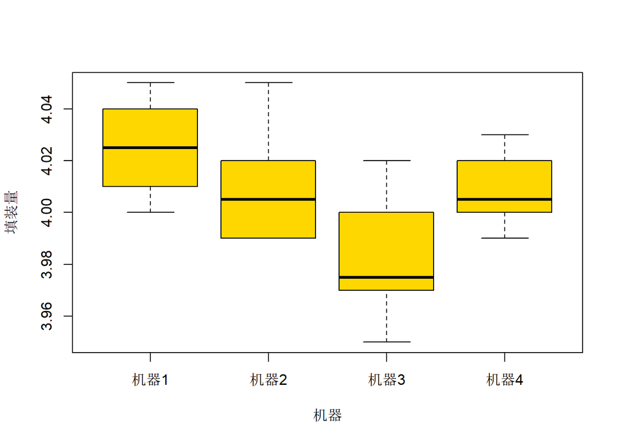

```r
attach(exercise8_1)
boxplot(填装量~机器,data=exercise8_1,col="gold",main="",ylab="填装量", xlab="机器")
```

```r
my_summary<-function(x){with(x,data.frame("均值"=mean(填装量),"标准差"=sd(填装量),n=length(填装量)))}
library(plyr)
ddply(exercise8_1,.(机器),my_summary)
```

```
##    机器     均值     标准差 n
## 1 机器1 4.025000 0.01870829 6
## 2 机器2 4.010000 0.02280351 6
## 3 机器3 3.981667 0.02483277 6
## 4 机器4 4.008333 0.01471960 6
```

```r
attach(exercise8_1)
model_1w<-aov(填装量~机器)
summary(model_1w)
```

```
##             Df   Sum Sq   Mean Sq F value Pr(>F)
## 机器         3 0.005846 0.0019486   4.576 0.0135 *
## Residuals   20 0.008517 0.0004258
## ---
## Signif. codes:  0 '***' 0.001 '**' 0.01 '*' 0.05 '.' 0.1 ' ' 1
```

```r
model_1w$coefficients
```

```
## (Intercept)   机器机器2   机器机器3   机器机器4
##  4.02500000 -0.01500000 -0.04333333 -0.01666667
```

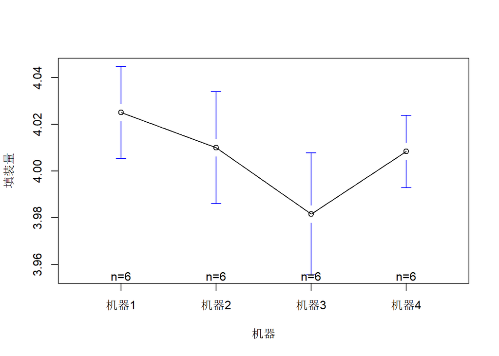

```r
library(gplots)
plotmeans(填装量~机器,data=exercise8_1)
```

### 8.1.2分析效应量

```r
library(DescTools)
model_1w<-aov(填装量~机器)
EtaSq(model_1w,anova=T)
```

```
##              eta.sq eta.sq.part          SS df           MS        F
## 机器      0.4070206   0.4070206 0.005845833  3 0.0019486111 4.575995
## Residuals 0.5929794          NA 0.008516667 20 0.0004258333       NA
##                    p
## 机器      0.01348501
## Residuals         NA
```

### 8.1.3分别采用LSD和HSD方法比较哪些机器填装量之间存在显著性差异

```r
library(agricolae)
model_1w<-aov(填装量~机器,data=exercise8_1)
LSD<-LSD.test(model_1w,"机器");LSD
```

```
## $statistics
##        MSerror Df    Mean        CV  t.value        LSD
##   0.0004258333 20 4.00625 0.5150884 2.085963 0.02485226
##
## $parameters
##         test p.ajusted name.t ntr alpha
##   Fisher-LSD      none   机器   4  0.05
##
## $means
##         填装量        std r      LCL      UCL  Min  Max    Q25   Q50
## 机器1 4.025000 0.01870829 6 4.007427 4.042573 4.00 4.05 4.0125 4.025
## 机器2 4.010000 0.02280351 6 3.992427 4.027573 3.99 4.05 3.9925 4.005
## 机器3 3.981667 0.02483277 6 3.964093 3.999240 3.95 4.02 3.9700 3.975
## 机器4 4.008333 0.01471960 6 3.990760 4.025907 3.99 4.03 4.0000 4.005
##          Q75
## 机器1 4.0375
## 机器2 4.0175
## 机器3 3.9950
## 机器4 4.0175
##
## $comparison
## NULL
##
## $groups
##         填装量 groups
## 机器1 4.025000      a
## 机器2 4.010000      a
## 机器4 4.008333      a
## 机器3 3.981667      b
##
## attr(,"class")
## [1] "group"
```

```r
library(DescTools)
PostHocTest(model_1w,method="lsd")
```

```
##
##   Posthoc multiple comparisons of means : Fisher LSD
##     95% family-wise confidence level
##
## $机器
##                     diff       lwr.ci       upr.ci   pval
## 机器2-机器1 -0.015000000 -0.039852260  0.009852260 0.2225
## 机器3-机器1 -0.043333333 -0.068185594 -0.018481073 0.0016 **
## 机器4-机器1 -0.016666667 -0.041518927  0.008185594 0.1772
## 机器3-机器2 -0.028333333 -0.053185594 -0.003481073 0.0275 *
## 机器4-机器2 -0.001666667 -0.026518927  0.023185594 0.8901
## 机器4-机器3  0.026666667  0.001814406  0.051518927 0.0367 *
##
## ---
## Signif. codes:  0 '***' 0.001 '**' 0.01 '*' 0.05 '.' 0.1 ' ' 1
```

```r
TukeyHSD(model_1w)
```

```
##   Tukey multiple comparisons of means
##     95% family-wise confidence level
##
## Fit: aov(formula = 填装量 ~ 机器, data = exercise8_1)
##
## $机器
##                     diff          lwr          upr     p adj
## 机器2-机器1 -0.015000000 -0.048346648  0.018346648 0.5982422
## 机器3-机器1 -0.043333333 -0.076679982 -0.009986685 0.0082001
## 机器4-机器1 -0.016666667 -0.050013315  0.016679982 0.5144408
## 机器3-机器2 -0.028333333 -0.061679982  0.005013315 0.1139540
## 机器4-机器2 -0.001666667 -0.035013315  0.031679982 0.9989889
## 机器4-机器3  0.026666667 -0.006679982  0.060013315 0.1470692
```

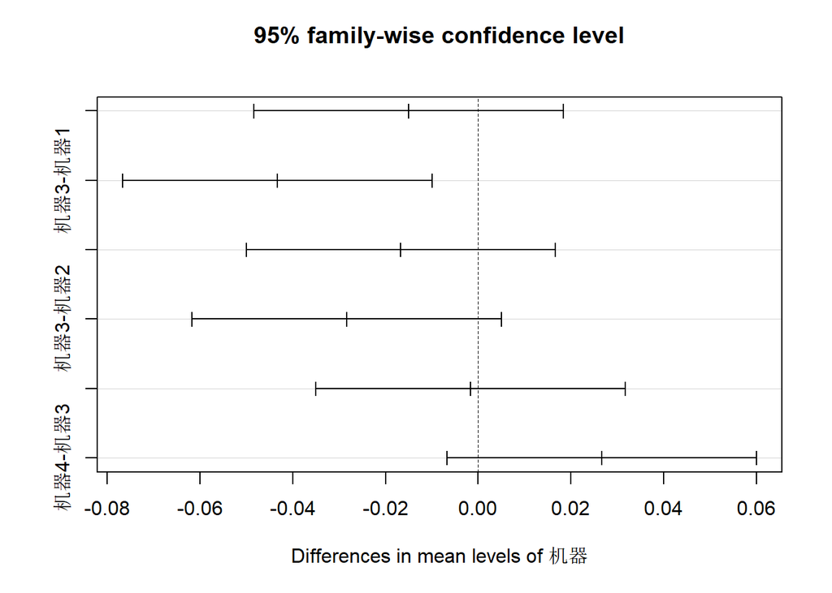

```r
plot(TukeyHSD(model_1w))
```

```r
library(agricolae)
HSD<-HSD.test(model_1w,"机器");HSD
```

```
## $statistics
##        MSerror Df    Mean        CV        MSD
##   0.0004258333 20 4.00625 0.5150884 0.03334665
##
## $parameters
##    test name.t ntr StudentizedRange alpha
##   Tukey   机器   4         3.958293  0.05
##
## $means
##         填装量        std r  Min  Max    Q25   Q50    Q75
## 机器1 4.025000 0.01870829 6 4.00 4.05 4.0125 4.025 4.0375
## 机器2 4.010000 0.02280351 6 3.99 4.05 3.9925 4.005 4.0175
## 机器3 3.981667 0.02483277 6 3.95 4.02 3.9700 3.975 3.9950
## 机器4 4.008333 0.01471960 6 3.99 4.03 4.0000 4.005 4.0175
##
## $comparison
## NULL
##
## $groups
##         填装量 groups
## 机器1 4.025000      a
## 机器2 4.010000     ab
## 机器4 4.008333     ab
## 机器3 3.981667      b
##
## attr(,"class")
## [1] "group"
```

### 8.1.4检验填装量是否满足正态性和方差齐性

```r
attach(exercise8_1)
shapiro.test(填装量)#正态性检验
```

```
##
##  Shapiro-Wilk normality test
##
## data:  填装量
## W = 0.97509, p-value = 0.7912
```

```r
bartlett.test(填装量~机器,data=exercise8_1)#方差齐性检验
```

```
##
##  Bartlett test of homogeneity of variances
##
## data:  填装量 by 机器
## Bartlett's K-squared = 1.3927, df = 3, p-value = 0.7073
```

## 8.2

### 8.2.1 检验管理者的水平不同是否会导致评分的显著差异，并分析其效应量

```r
load("C:/exercise/ch8/exercise8_2.RData")
exercise8_2
```

```
##        管理者 评分
## 1  高层管理者    7
## 2  高层管理者    7
## 3  高层管理者    8
## 4  高层管理者    7
## 5  高层管理者    9
## 6  高层管理者    8
## 7  中层管理者    8
## 8  中层管理者    9
## 9  中层管理者    8
## 10 中层管理者   10
## 11 中层管理者    9
## 12 中层管理者   10
## 13 低层管理者    5
## 14 低层管理者    6
## 15 低层管理者    5
## 16 低层管理者    7
## 17 低层管理者    4
## 18 低层管理者    8
```

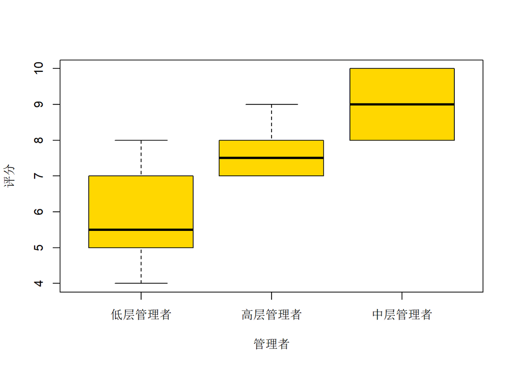

```r
attach(exercise8_2)
boxplot(评分~管理者,data=exercise8_1,col="gold",main="",ylab="评分", xlab="管理者")
```

```r
my_summary<-function(x){with(x,data.frame("均值"=mean(评分),"标准差"=sd(评分),n=length(评分)))}
library(plyr)
ddply(exercise8_2,.(管理者),my_summary)
```

```
##       管理者     均值    标准差 n
## 1 低层管理者 5.833333 1.4719601 6
## 2 高层管理者 7.666667 0.8164966 6
## 3 中层管理者 9.000000 0.8944272 6
```

```r
attach(exercise8_2)
model_1w<-aov(评分~管理者)
summary(model_1w)
```

```
##             Df Sum Sq Mean Sq F value   Pr(>F)
## 管理者       2  30.33  15.167   12.52 0.000633 ***
## Residuals   15  18.17   1.211
## ---
## Signif. codes:  0 '***' 0.001 '**' 0.01 '*' 0.05 '.' 0.1 ' ' 1
```

```r
model_1w$coefficients
```

```
##      (Intercept) 管理者高层管理者 管理者中层管理者
##         5.833333         1.833333         3.166667
```

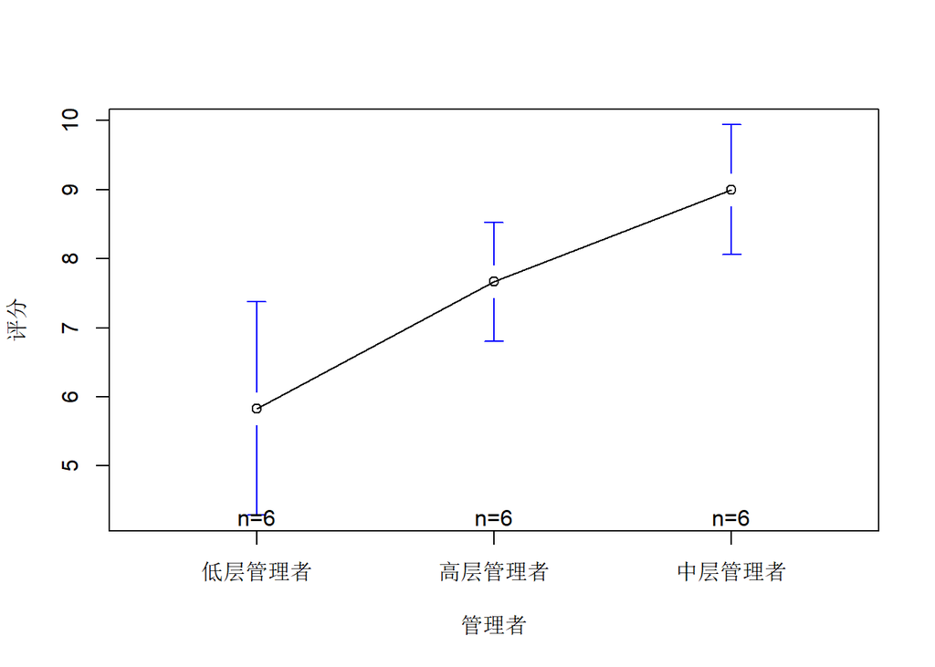

```r
library(gplots)
plotmeans(评分~管理者,data=exercise8_2)
```

```r
library(DescTools)
model_1w<-aov(评分~管理者)
EtaSq(model_1w,anova=T)
```

```
##              eta.sq eta.sq.part       SS df        MS        F
## 管理者    0.6254296   0.6254296 30.33333  2 15.166667 12.52294
## Residuals 0.3745704          NA 18.16667 15  1.211111       NA
##                      p
## 管理者    0.0006331423
## Residuals           NA
```

### 8.2.2分别采用LSD和HSD方法比较管理者评分之间存在差异

```r
library(agricolae)
model_1w<-aov(评分~管理者,data=exercise8_2)
LSD<-LSD.test(model_1w,"管理者");LSD
```

```
## $statistics
##    MSerror Df Mean      CV t.value      LSD
##   1.211111 15  7.5 14.6734 2.13145 1.354274
##
## $parameters
##         test p.ajusted name.t ntr alpha
##   Fisher-LSD      none 管理者   3  0.05
##
## $means
##                评分       std r      LCL      UCL Min Max  Q25 Q50  Q75
## 低层管理者 5.833333 1.4719601 6 4.875717 6.790949   4   8 5.00 5.5 6.75
## 高层管理者 7.666667 0.8164966 6 6.709051 8.624283   7   9 7.00 7.5 8.00
## 中层管理者 9.000000 0.8944272 6 8.042384 9.957616   8  10 8.25 9.0 9.75
##
## $comparison
## NULL
##
## $groups
##                评分 groups
## 中层管理者 9.000000      a
## 高层管理者 7.666667      a
## 低层管理者 5.833333      b
##
## attr(,"class")
## [1] "group"
```

```r
library(DescTools)
PostHocTest(model_1w,method="lsd")
```

```
##
##   Posthoc multiple comparisons of means : Fisher LSD
##     95% family-wise confidence level
##
## $管理者
##                           diff     lwr.ci   upr.ci    pval
## 高层管理者-低层管理者 1.833333  0.4790597 3.187607 0.01132 *
## 中层管理者-低层管理者 3.166667  1.8123930 4.520940 0.00016 ***
## 中层管理者-高层管理者 1.333333 -0.0209403 2.687607 0.05321 .
##
## ---
## Signif. codes:  0 '***' 0.001 '**' 0.01 '*' 0.05 '.' 0.1 ' ' 1
```

```r
TukeyHSD(model_1w)
```

```
##   Tukey multiple comparisons of means
##     95% family-wise confidence level
##
## Fit: aov(formula = 评分 ~ 管理者, data = exercise8_2)
##
## $管理者
##                           diff       lwr      upr     p adj
## 高层管理者-低层管理者 1.833333  0.182961 3.483706 0.0287632
## 中层管理者-低层管理者 3.166667  1.516294 4.817039 0.0004519
## 中层管理者-高层管理者 1.333333 -0.317039 2.983706 0.1237560
```

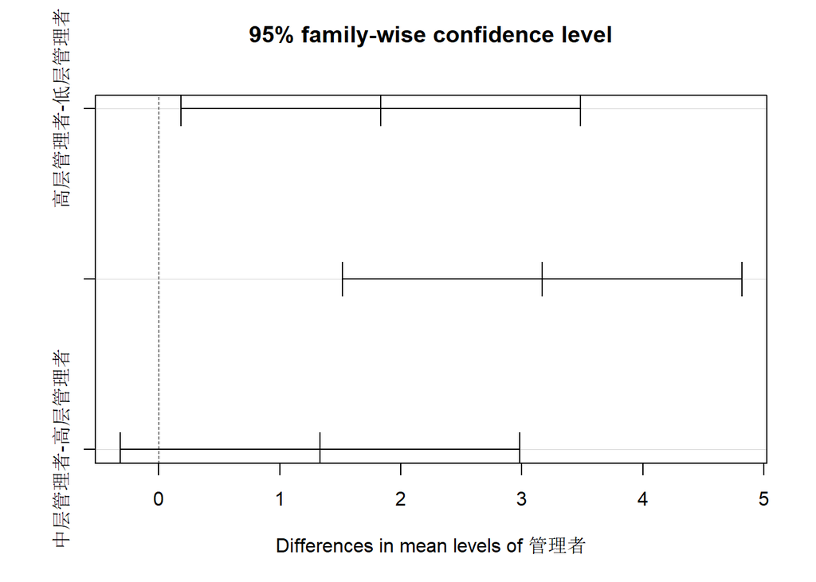

```r
plot(TukeyHSD(model_1w))
```

```r
library(agricolae)
HSD<-HSD.test(model_1w,"管理者");HSD
```

```
## $statistics
##    MSerror Df Mean      CV      MSD
##   1.211111 15  7.5 14.6734 1.650372
##
## $parameters
##    test name.t ntr StudentizedRange alpha
##   Tukey 管理者   3         3.673378  0.05
##
## $means
##                评分       std r Min Max  Q25 Q50  Q75
## 低层管理者 5.833333 1.4719601 6   4   8 5.00 5.5 6.75
## 高层管理者 7.666667 0.8164966 6   7   9 7.00 7.5 8.00
## 中层管理者 9.000000 0.8944272 6   8  10 8.25 9.0 9.75
##
## $comparison
## NULL
##
## $groups
##                评分 groups
## 中层管理者 9.000000      a
## 高层管理者 7.666667      a
## 低层管理者 5.833333      b
##
## attr(,"class")
## [1] "group"
```

### 8.2.3检验满意度评分是否满足正态性和方差齐性

```r
attach(exercise8_2)
shapiro.test(评分)#正态性检验
```

```
##
##  Shapiro-Wilk normality test
##
## data:  评分
## W = 0.94141, p-value = 0.3063
```

```r
bartlett.test(评分~管理者,data=exercise8_2)#方差齐性检验
```

```
##
##  Bartlett test of homogeneity of variances
##
## data:  评分 by 管理者
## Bartlett's K-squared = 1.9746, df = 2, p-value = 0.3726
```

```r
attach(exercise8_2)
ks.test(exercise8_2$评分,"pnorm",mean(exercise8_2$评分),sd(exercise8_2$评分))
```

```
##
##  One-sample Kolmogorov-Smirnov test
##
## data:  exercise8_2$评分
## D = 0.17195, p-value = 0.6617
## alternative hypothesis: two-sided
```

## 8.3

### 8.3.1分析3个企业生产的电池平均寿命之间有无显著差异，并分析其效应量

```r
load("C:/exercise/ch8/exercise8_3.RData")
exercise8_3
```

```
##    企业 电池寿命
## 1     A       50
## 2     A       50
## 3     A       43
## 4     A       40
## 5     A       39
## 6     B       32
## 7     B       28
## 8     B       30
## 9     B       34
## 10    B       26
## 11    C       45
## 12    C       42
## 13    C       38
## 14    C       48
## 15    C       40
```

```r
my_summary<-function(x){with(x,data.frame("均值"=mean(电池寿命),"标准差"=sd(电池寿命),n=length(电池寿命)))}
library(plyr)
ddply(exercise8_3,.(企业),my_summary)
```

```
##   企业 均值   标准差 n
## 1    A 44.4 5.319774 5
## 2    B 30.0 3.162278 5
## 3    C 42.6 3.974921 5
```

```r
attach(exercise8_3)
model_1w<-aov(电池寿命~企业)
summary(model_1w)
```

```
##             Df Sum Sq Mean Sq F value  Pr(>F)
## 企业         2  615.6  307.80   17.07 0.00031 ***
## Residuals   12  216.4   18.03
## ---
## Signif. codes:  0 '***' 0.001 '**' 0.01 '*' 0.05 '.' 0.1 ' ' 1
```

```r
model_1w$coefficients
```

```
## (Intercept)       企业B       企业C
##        44.4       -14.4        -1.8
```

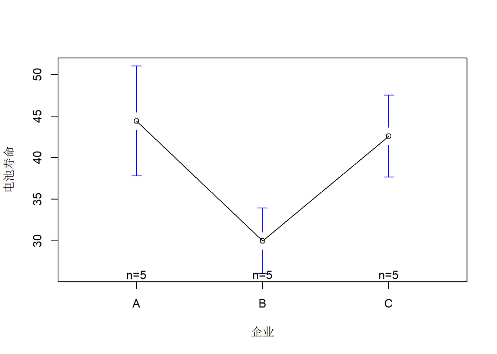

```r
library(gplots)
plotmeans(电池寿命~企业,data=exercise8_3)
```

```r
library(DescTools)
model_1w<-aov(电池寿命~企业)
EtaSq(model_1w,anova=T)
```

```
##              eta.sq eta.sq.part    SS df        MS        F            p
## 企业      0.7399038   0.7399038 615.6  2 307.80000 17.06839 0.0003096019
## Residuals 0.2600962          NA 216.4 12  18.03333       NA           NA
```

### 8.3.2如有差异，用HSD法检验哪些企业之间有差异

```r
TukeyHSD(model_1w)
```

```
##   Tukey multiple comparisons of means
##     95% family-wise confidence level
##
## Fit: aov(formula = 电池寿命 ~ 企业)
##
## $企业
##      diff        lwr       upr     p adj
## B-A -14.4 -21.565255 -7.234745 0.0004622
## C-A  -1.8  -8.965255  5.365255 0.7847311
## C-B  12.6   5.434745 19.765255 0.0013991
```

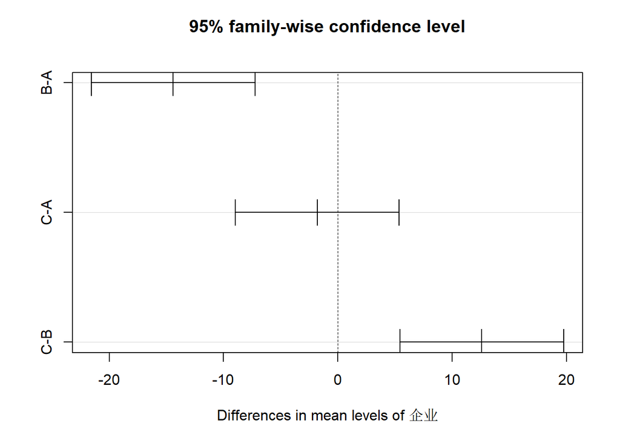

```r
plot(TukeyHSD(model_1w))
```

```r
library(agricolae)
HSD<-HSD.test(model_1w,"企业");HSD
```

```
## $statistics
##    MSerror Df Mean       CV      MSD
##   18.03333 12   39 10.88863 7.165255
##
## $parameters
##    test name.t ntr StudentizedRange alpha
##   Tukey   企业   3         3.772929  0.05
##
## $means
##   电池寿命      std r Min Max Q25 Q50 Q75
## A     44.4 5.319774 5  39  50  40  43  50
## B     30.0 3.162278 5  26  34  28  30  32
## C     42.6 3.974921 5  38  48  40  42  45
##
## $comparison
## NULL
##
## $groups
##   电池寿命 groups
## A     44.4      a
## C     42.6      a
## B     30.0      b
##
## attr(,"class")
## [1] "group"
```